# Practical Machine Learning Course Project

Jhon Sebastian Villarreal

28/8/2020

## Introduction

The present project propose a machine learning model to predict the way a sample of participants does barbell lifts, using data the Weight Lifting Exercises (WLE) Dataset collected by the [Groupware research team](http://groupware.les.inf.puc-rio.br/har#weight_lifting_exercises), measure with accelerometers on 4 parts of the body: the belt, arm, forearm and dumbbell. The document is divided in three sections: One first section for the preprocessing of the training data using Principal Component Analysis, followed by the estimation of a random forest model and a GBM model to select the most accurate; and the final section predicting the class of 20 observations using the selected model.

### 1. Preprocessing

The variable we are trying to predict is the “classe” variable from the WLE dataset. We can see below that this variable has imbalanced levels in the training data, for which the most frequent one corresponds to the type “A”, also refer as the correct way to perform the exercise. The other levels correspond to 4 different incorrect ways of performance.

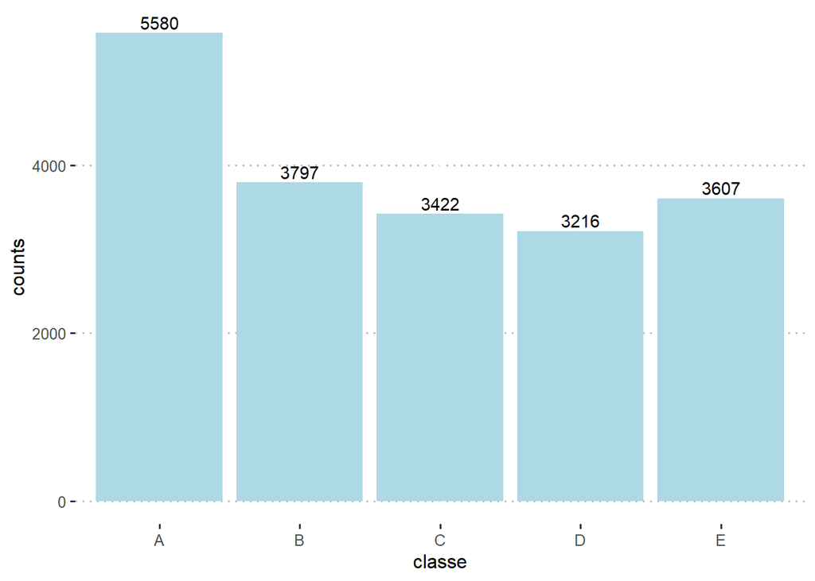

In the dataset, some of the variables are available for every moment a participant does the exercise no matter the type of performance, while the rest are conditioned to the time a new window is presented, so they report a missing value for every time there is not new window.

As the algorithm of the present project focus on predict how well a person does the exercise, this second type of variables could skew the parameters, because they do not have a counterfactual information to be compare with in the moments where there is not a new window. For this reason, it was decided not to involve these variables in the training data, while just select the dummy variable indicating the presence of a new window. If this variable results relevant, it could be that the presence of a new window and its underlying variables influence the performance prediction.

This selection process let us with 13 performance measures for every part of the body.

```r
#belt_new_window
data.frame(training[,12:36])
#arm_new_window
data.frame(c(training[,50:59], training[,69:83])))
#dumbbell_new_window
data.frame(c(training[,87:101], training[,103:112]))
#forearm_new_window
data.frame(c(training[,125:139], training[,141:150])

training <- training[,-(c(12:36,50:59,69:83,87:101,103:112,125:139,141:150))]
#60 variables in total
```

Also, the dataset recognizes the “new window” and “classe” variables as characters, so we must change their structure in order to avoid any estimation problem related with this issue.

```r
#Incorrect variable types
str(c(training$new_window, training$classe)) #Recognized as character
```

We correct their structure to the real one: “new window” as dummy and “classe” as factor

```r
#Changing to the correct variable types
#New window
dummies <- dummyVars(classe ~ new_window, data = training)
dummy <- predict(dummies, newdata = training)
training$new_window <- dummy[,2]
#Classe
training$classe <- as.factor(training$classe)
str(training$new_window); str(training$classe)
```

With the number of predictors have been reduced, we can build the prediction algorithm. For this project, the preprocessing will be accomplished throught Principal Component Analysis (PCA), in order to reduce the variables to components containing most of the variability of the performance measures for every part of the body.For this propose, we first observe the correlation between the selected variables in the training dataset.

```r
M <- abs(cor(training[,7:59]))
diag(M) <- 0
which(M > 0.7, arr.ind = TRUE)
```

[output not shown]

```r
#BELT
belt <- training[,8:20]; beltpca <- prcomp(belt); belt_pr <- summary(beltpca)
#ARM
arm <- training[,21:33]; armpca <- prcomp(arm); arm_pr <- summary(armpca)
#DUMBBELL
dbell <- training[,34:46]; dbellpca <- prcomp(dbell); dbell_pr <- summary(dbellpca)
#FOREARM
farm <- training[,47:59]; farmpca <- prcomp(farm); farm_pr <- summary(farmpca)
```

we are looking for components containing 80% of the variability in every case, assuming this quantity is enough to train the model and predict the classe variable. For this, we must observe the importance of every component and select those components that a cumulative proportion of variance equal or greater than 80%.

```r
#Belt PCAs importance
belt_pr$importance[3,]
#Arm PCAs importance
arm_pr$importance[3,]
#Dumbbell PCAs importance
dbell_pr$importance[3,]
#Forearm PCAs importance
farm_pr$importance[3,]
```

[output not shown]

we select these components and the new window dummy to be the training predictors.

```r
pr_belt <- data.frame( belt1 = belt_pr$x[,1], belt2 = belt_pr$x[,2])
pr_arm <- data.frame(arm1 = arm_pr$x[,1], arm2 = arm_pr$x[,2])
pr_dbel <- data.frame(dbel1 = dbell_pr$x[,1], dbel2 = dbell_pr$x[,2])
pr_farm <- data.frame(farm1 = farm_pr$x[,1], farm2 = farm_pr$x[,2], farm3 = farm_pr$x[,3])
new_training <- data.frame(new_window = training$new_window, pr_belt, pr_arm, pr_dbel, pr_farm, classe = training$classe)
```

### 2. Machine Learning Model Estimation

With the PCA preprocess above, we have obtain the predictors to estimate the machine learning model. We are going to choose between two prediction algorithms, a random forest and a Gradient Boosting Machine; but first, we opt to complement the PCAs with a 10-fold cross-validation. This will help us to control the imbalanced classes in the classe variable and to obtain a better training of the models.

```r
set.seed(34567)
#10-fold cross validation
cross_v <- trainControl(method = "cv", number = 10)
```

With the cross validation accomplished, we proceed to train the models with the PCAs and the new window variable as predictors.

```r
##Random Forest model
set.seed(5432)
modfit1 <- train(classe ~., data = new_training, method = "rf", trcontrol = cross_v)
modfit1
```

[output not shown]

```r
## GBM model
modfit2 <- train(y = training$classe, x = new_training[,-11], method = "gbm", distribution = "multinomial", trControl = cross_v, verbose = FALSE)
modfit2
```

[output not shown]

## 3. Predicting the testing data.

```r
testing <- testing[,-(c(12:36,50:59,69:83,87:101,103:112,125:139,141:150))]
```

Then, we transform the “new_window” predictor to dummy:

```r
testing$new_window[testing$new_window == "no"] <- 0
testing$new_window[testing$new_window == "yes"] <- 1
testing$new_window <- as.numeric(testing$new_window)
```

Now, we predict the principal components for this data using the estimated parameters in the training data preprocessing.

```r
#belt
belttest <- predict(beltpca, newdata = testing)
testpr_belt <- data.frame(belt1 = belttest[,1], belt2 = belttest[,2])
#arm
armtest <- predict(armpca, newdata = testing)
testpr_arm <- data.frame(arm1 = armtest[,1], arm2 = armtest[,2])
#dumbbell
dbelltest <- predict(dbellpca, newdata = testing)
testpr_dbell <- data.frame(dbel1 = dbelltest[,1], dbel2 = dbelltest[,2])
#forearm
farmtest <- predict(farmpca, newdata = testing)
testpr_farm <- data.frame(farm1 = farmtest[,1], farm2 = farmtest[,2], farm3 = farmtest[,3] )
```

Finally, we construct the new testing dataset and predict the exercise type. At the end, if we also do the prediction with the GBM model, this results with 5 different classifications when comparing with the random forest model.

```r
new_testing <- data.frame(new_window = testing$new_window, testpr_belt, testpr_arm, testpr_dbell, testpr_farm)

#Predict with Random Forest model
rf_pred <- predict(modfit1, newdata = new_testing)
data.frame(testing$problem_id, rf_pred)

#Predict with GBM model
gbm_pred <- predict(modfit2, newdata = new_testing)
which(rf_pred != gbm_pred, arr.ind = TRUE)

different <- rf_pred != gbm_pred
predictions <- data.frame(rf_pred, gbm_pred, different)
```

```r
#RF GBM Are different?
#B  A   TRUE
#A  A   FALSE
#B  A   TRUE
#A  A   FALSE
#A  A   FALSE
#E  E   FALSE
#D  D   FALSE
#B  B   FALSE
#A  A   FALSE
#A  A   FALSE
#B  A   TRUE
#C  C   FALSE
#B  E   TRUE
#A  A   FALSE
#E  E   FALSE
#E  E   FALSE
#A  A   FALSE
#B  B   FALSE
#B  A   TRUE
#B  B   FALSE
```